# State MSM Profile: **Louisiana**

### Background & Methods

In 2015-2016, researchers at Emory University partnered with colleagues at the Centers for Disease Control and Prevention (CDC) to develop methods to estimate the number of men who have sex with men (MSM) residing in each county in the United States. Using population and housing data from the [American Community Survey](https://www.census.gov/programs-surveys/acs/) and estimates from two peer-reviewed publications ([Oster et al., 2015](http://www.ncbi.nlm.nih.gov/pubmed/26115985) & [Purcell et al., 2012](http://www.ncbi.nlm.nih.gov/pubmed/23049658)), they derived an indirect estimate of MSM population sizes that took into account both the urbanicity of the county as well as its density of households with a male householder and a male same-sex partner.

The full methodology is published in the *Journal of Medical Internet Research - Public Health and Surveillance*:

> [Grey JA, Bernstein KT, Sullivan PS, Purcell DW, Chesson HW, Gift TL, Rosenberg ES. Estimating the population sizes of men who have sex with men in US states and counties using data from the American Community Survey. JMIR Public Health Surveill 2016;2(1):e14. DOI: 10.2196/publichealth.5365](http://publichealth.jmir.org/2016/1/e14/)

### Overview of MSM in Louisiana

An estimated **41,492** men who have sex with men (MSM) resided in Louisiana in 2013, representing 0.9% of the 4,503,084 MSM in the United States. Of the 1,665,801 adult men of Louisiana, 2.5% had had sex with another man in the past 5 years, which was less than the overall percentage of adult men in the United States who were MSM (3.9%).

Most MSM in Louisiana resided in counties within medium or small metropolitan areas (40.8%). Including both central and fringe counties, 51.0% resided in a large metropolitan area.

##### **Percentage of MSM by urbanicity, United States and Louisiana, 2013**

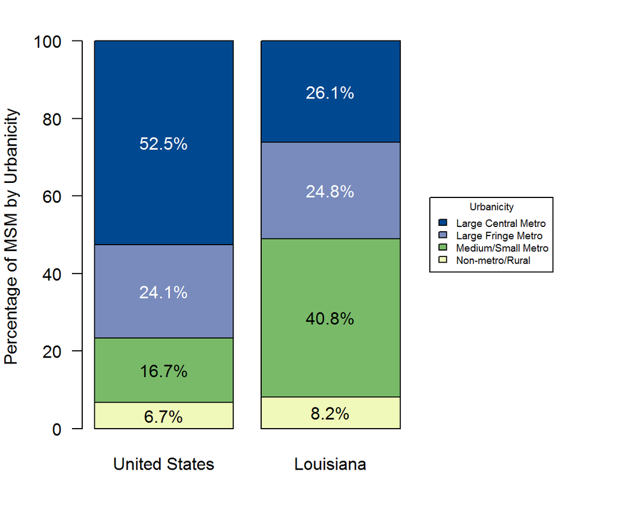

### MSM in Louisiana Counties

Among counties or county-equivalent areas in Louisiana, Orleans Parish had the largest population of MSM at 10,848, representing 26.1% of all MSM in the state. Orleans Parish also had the highest percentage of MSM among adult men in Louisiana at 8.1%. This was greater than the percentage for Louisiana as a whole, which was 2.5% of adult men.

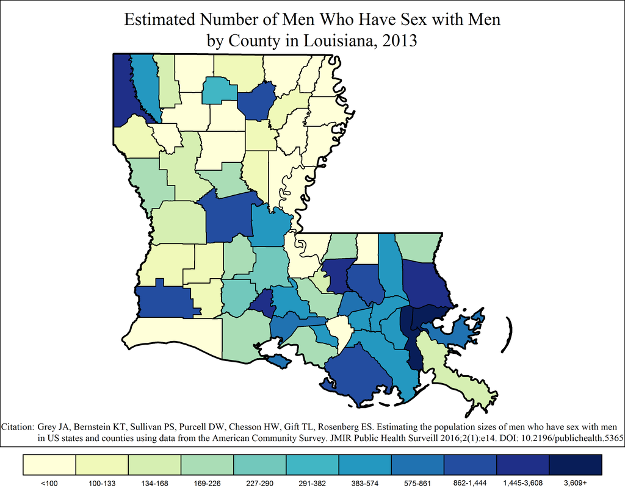

Note: Range cutpoints for the map are based on the distribution of MSM among all counties in the United States.

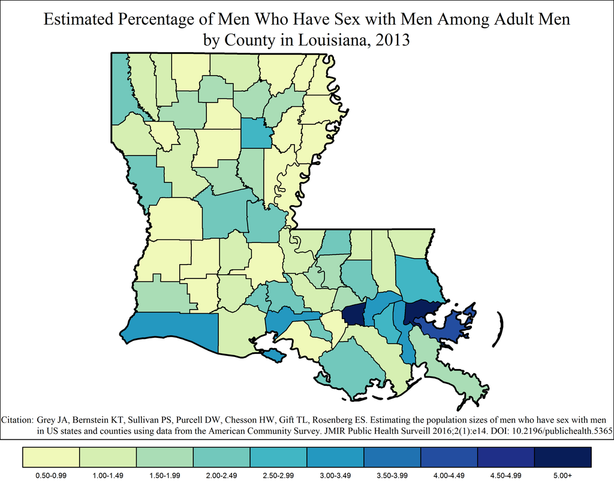

### MSM in Louisiana Metropolitan Statistical Areas

#### New Orleans-Metairie Metropolitan Statistical Area

The New Orleans-Metairie MSA had the largest metropolitan population of MSM in Louisiana at 21,154, or 51.0% of all MSM in the state. Of the 445,151 adult men in New Orleans-Metairie, an estimated 4.8% were MSM.

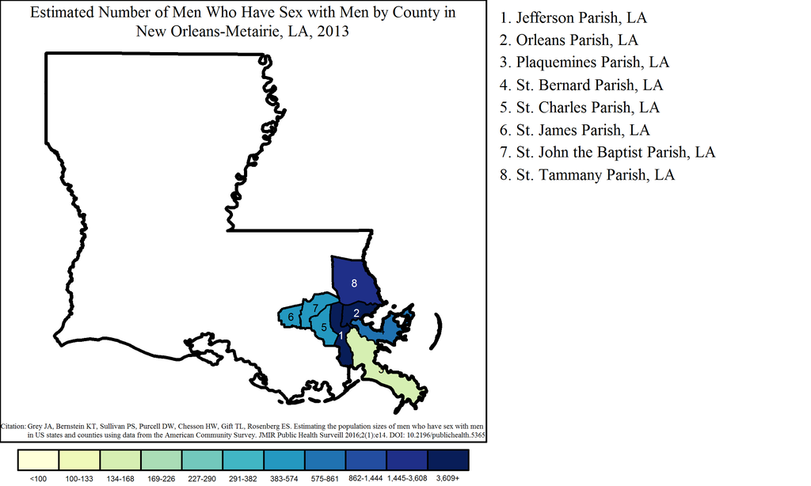

Note: Range cutpoints for the map are based on the distribution of MSM among all counties in the United States.

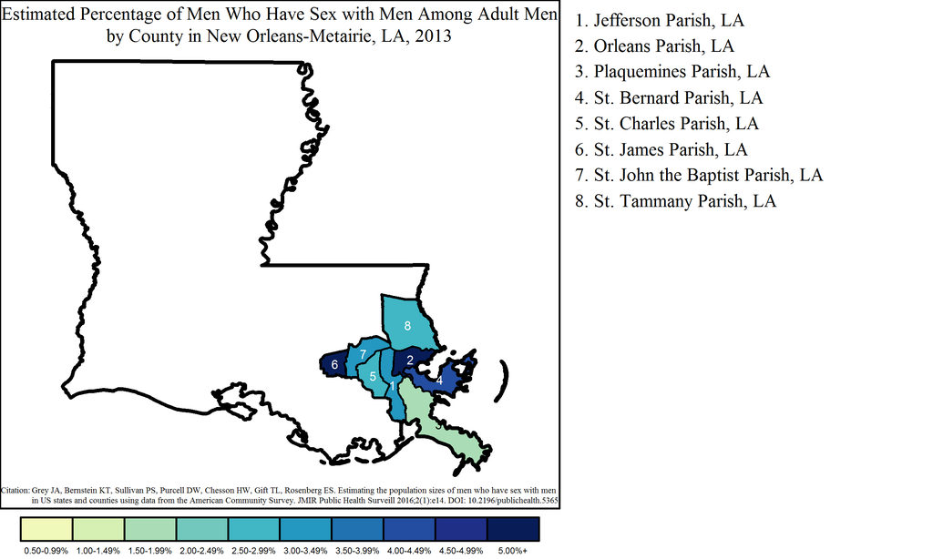

#### Baton Rouge Metropolitan Statistical Area

The Baton Rouge MSA had a population of 5,320 MSM, or 12.8% of all MSM in Louisiana. Of the 296,060 adult men in Baton Rouge, an estimated 1.8% were MSM.

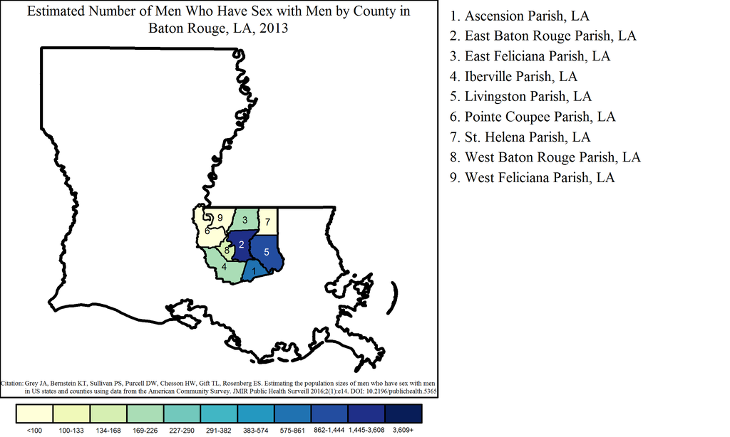

Note: Range cutpoints for the map are based on the distribution of MSM among all counties in the United States.

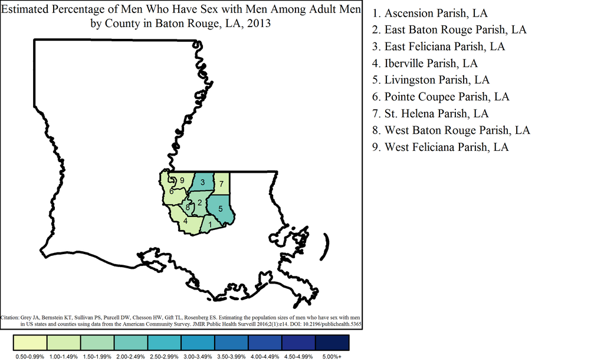

#### Lafayette Metropolitan Statistical Area

The Lafayette MSA had a population of 3,601 MSM, or 8.7% of all MSM in Louisiana. Of the 168,663 adult men in Lafayette, an estimated 2.1% were MSM.

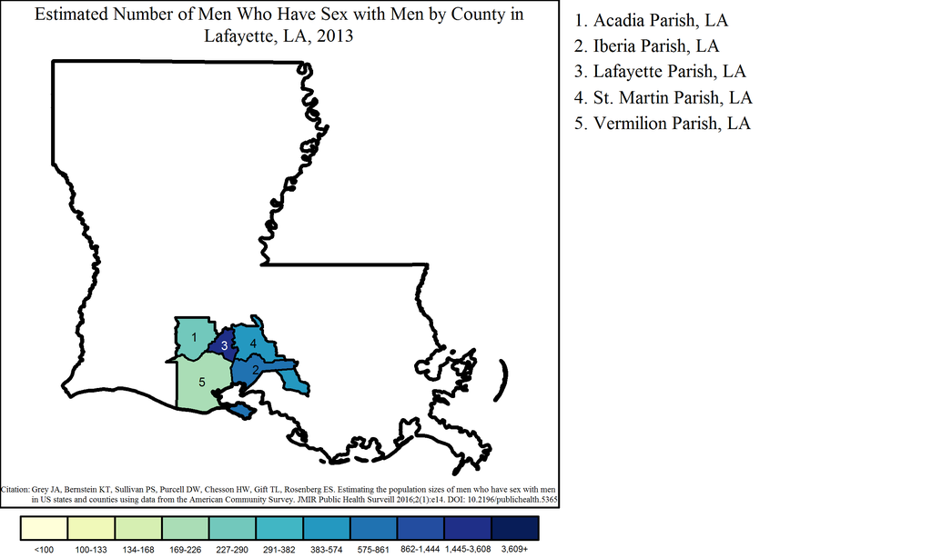

Note: Range cutpoints for the map are based on the distribution of MSM among all counties in the United States.

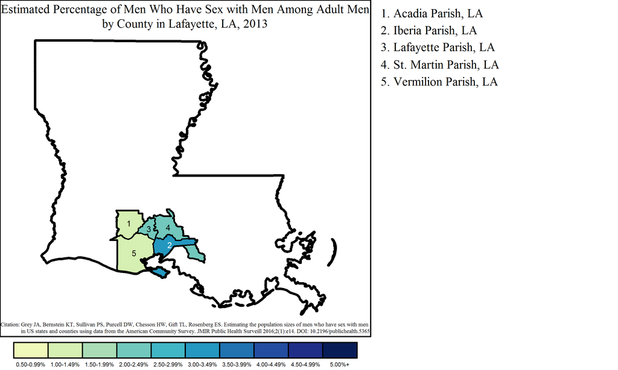

#### Shreveport-Bossier City Metropolitan Statistical Area

The Shreveport-Bossier City MSA had a population of 2,579 MSM, or 6.2% of all MSM in Louisiana. Of the 157,539 adult men in Shreveport-Bossier City, an estimated 1.6% were MSM.

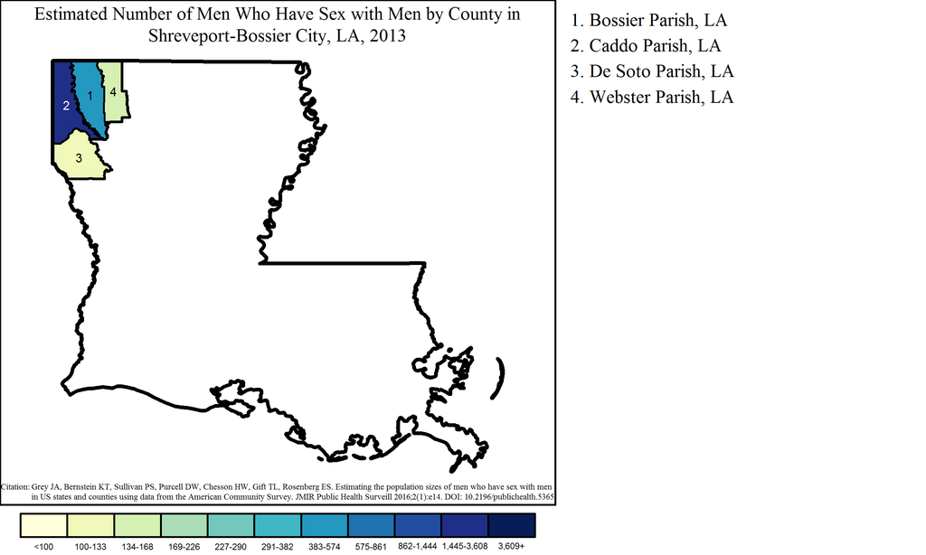

Note: Range cutpoints for the map are based on the distribution of MSM among all counties in the United States.

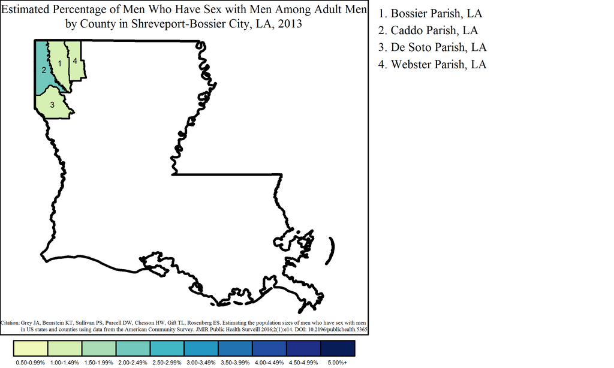

#### Houma-Thibodaux Metropolitan Statistical Area

The Houma-Thibodaux MSA had a population of 1,445 MSM, or 3.5% of all MSM in Louisiana. Of the 76,264 adult men in Houma-Thibodaux, an estimated 1.9% were MSM.

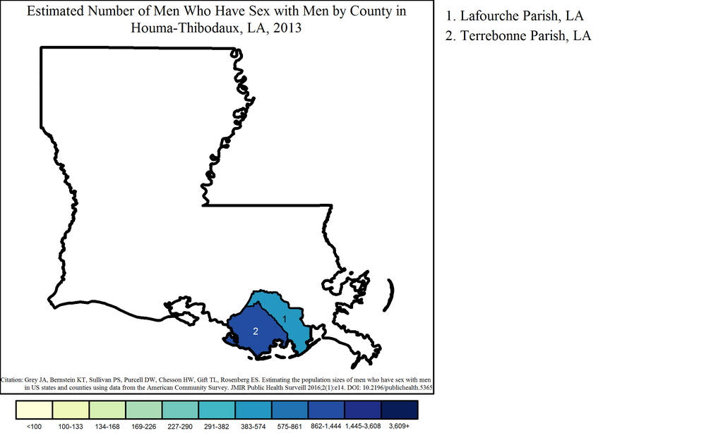

Note: Range cutpoints for the map are based on the distribution of MSM among all counties in the United States.

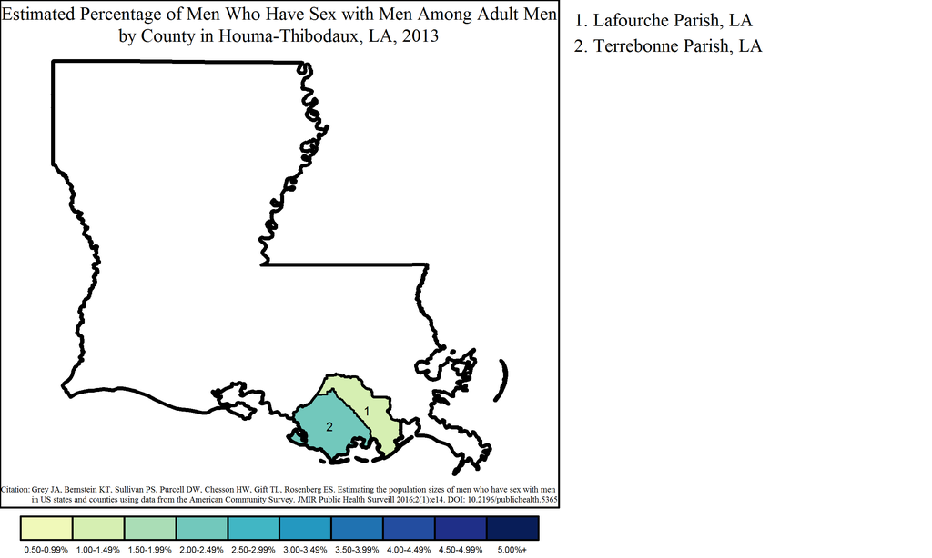

#### Alexandria Metropolitan Statistical Area

The Alexandria MSA had a population of 1,199 MSM, or 2.9% of all MSM in Louisiana. Of the 56,364 adult men in Alexandria, an estimated 2.1% were MSM.

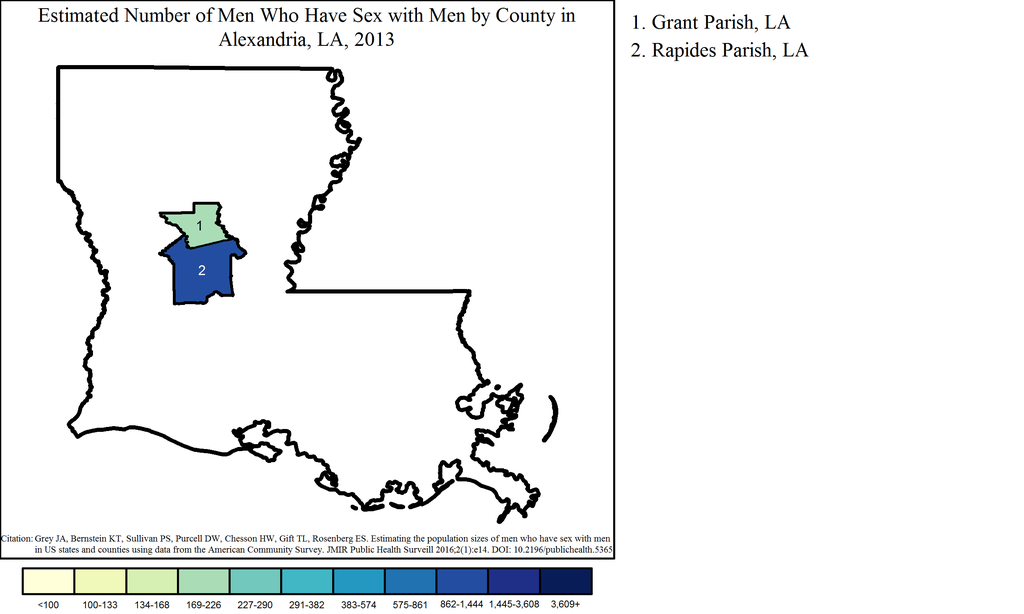

Note: Range cutpoints for the map are based on the distribution of MSM among all counties in the United States.

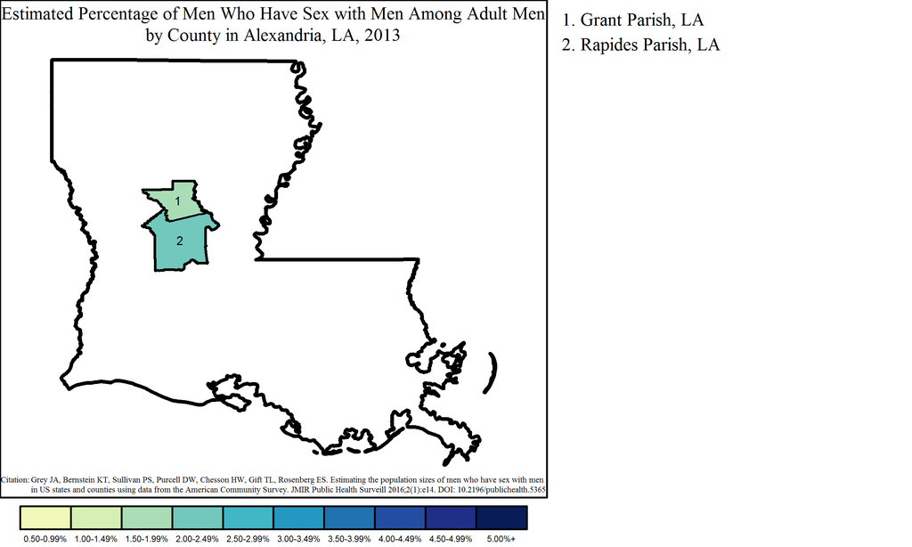

#### Lake Charles Metropolitan Statistical Area

The Lake Charles MSA had a population of 1,159 MSM, or 2.8% of all MSM in Louisiana. Of the 72,004 adult men in Lake Charles, an estimated 1.6% were MSM.

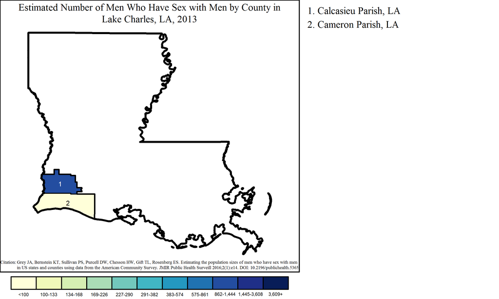

Note: Range cutpoints for the map are based on the distribution of MSM among all counties in the United States.

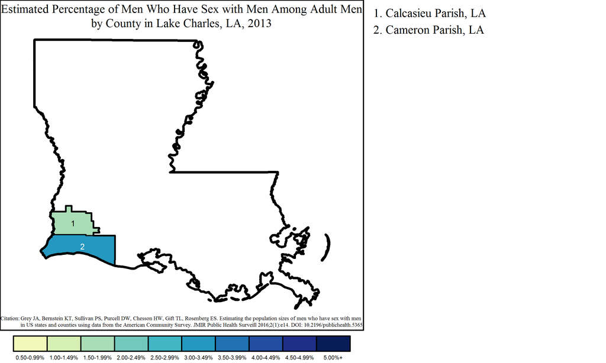

#### Monroe Metropolitan Statistical Area

The Monroe MSA had a population of 1,093 MSM, or 2.6% of all MSM in Louisiana. Of the 61,991 adult men in Monroe, an estimated 1.8% were MSM.

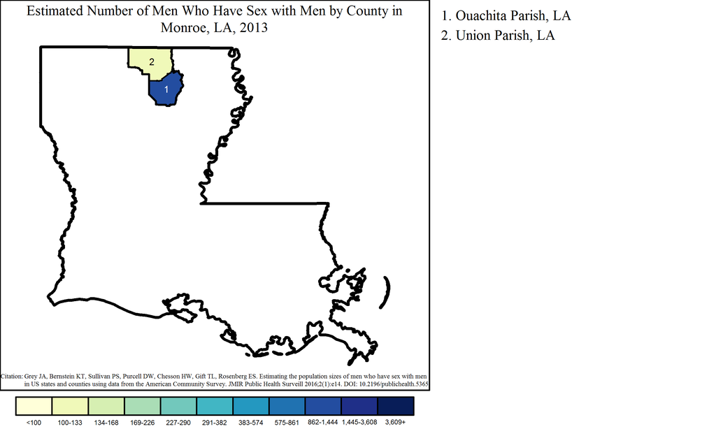

Note: Range cutpoints for the map are based on the distribution of MSM among all counties in the United States.

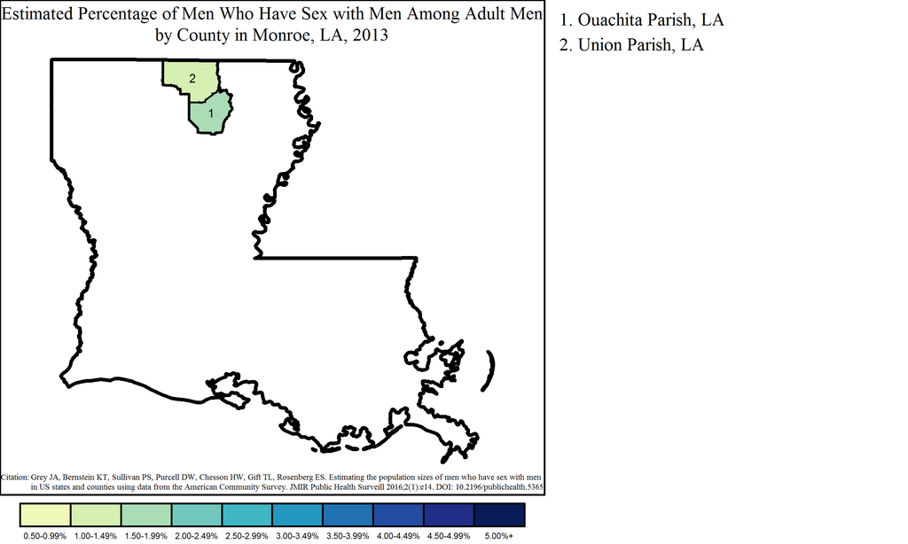

#### Hammond Metropolitan Statistical Area

The Hammond MSA had a population of 546 MSM, or 1.3% of all MSM in Louisiana. Of the 43,685 adult men in Hammond, an estimated 1.2% were MSM.

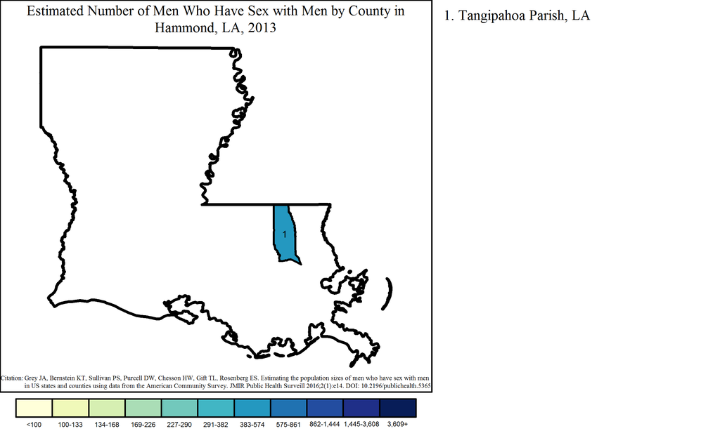

Note: Range cutpoints for the map are based on the distribution of MSM among all counties in the United States.

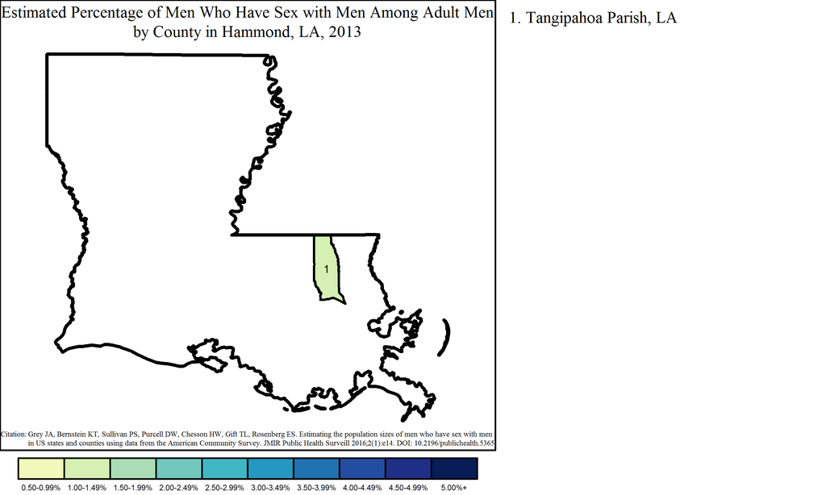